# Biostat M280 Homework 4

Due Mar 16 @ 11:59PM

Lumi Huang

```r
library(sparklyr)
library(devtools)
library(dplyr)
```

```r
library(ggplot2)
library(ggmap)
library(stringr)
library(maps)
library(mapdata)
Sys.setenv(SPARK_HOME="/usr/lib/spark")
config <- spark_config()
sc <- spark_connect(master = "yarn-client", config = config)
sc
```

[output not shown]

```r
flights_tbl <- tbl(sc, 'flights')
#saveRDS(flights_tbl, file = "flight_tbl.rds")
#flights_tbl <- read_rds("flight_tbl.rds")
flights_tbl %>% print(width = Inf)
```

```
## # Source:   table<flights> [?? x 29]
## # Database: spark_connection
##     year month dayofmonth dayofweek deptime crsdeptime arrtime crsarrtime
##    <int> <int>      <int>     <int>   <int>      <int>   <int>      <int>
##  1    NA    NA         NA        NA      NA         NA      NA         NA
##  2  1987    10         14         3     741        730     912        849
##  3  1987    10         15         4     729        730     903        849
##  4  1987    10         17         6     741        730     918        849
##  5  1987    10         18         7     729        730     847        849
##  6  1987    10         19         1     749        730     922        849
##  7  1987    10         21         3     728        730     848        849
##  8  1987    10         22         4     728        730     852        849
##  9  1987    10         23         5     731        730     902        849
## 10  1987    10         24         6     744        730     908        849
##    uniquecarrier flightnum tailnum actualelapsedtime crselapsedtime
```

[output cut: 48 more lines]

```r
airlines_tbl <- tbl(sc, 'airlines')
#saveRDS(airlins_tbl, file = "airlines_tbl.rds")
#airlines_tbl <- read_rds("airlines_tbl.rds")
airlines_tbl %>% print(width = Inf)
```

```
## # Source:   table<airlines> [?? x 2]
## # Database: spark_connection
##    code  description
##    <chr> <chr>
##  1 Code  Description
##  2 02Q   Titan Airways
##  3 04Q   Tradewind Aviation
##  4 05Q   Comlux Aviation, AG
##  5 06Q   Master Top Linhas Aereas Ltd.
##  6 07Q   Flair Airlines Ltd.
##  7 09Q   Swift Air, LLC d/b/a Eastern Air Lines d/b/a Eastern
##  8 0BQ   DCA
##  9 0CQ   ACM AIR CHARTER GmbH
## 10 0FQ   Maine Aviation Aircraft Charter, LLC
## # ... with more rows
```

```r
airports_tbl <- tbl(sc, 'airports')
#saveRDS(airports_tbl, "airports_tbl.rds")
#airports_tbl <- read_rds("airports_tbl.rds")
airports_tbl %>% print(width = Inf)
```

```
## # Source:   table<airports> [?? x 12]
## # Database: spark_connection
##    id    name                                        city
##    <chr> <chr>                                       <chr>
##  1 1     Goroka Airport                              Goroka
##  2 2     Madang Airport                              Madang
##  3 3     Mount Hagen Kagamuga Airport                Mount Hagen
##  4 4     Nadzab Airport                              Nadzab
##  5 5     Port Moresby Jacksons International Airport Port Moresby
##  6 6     Wewak International Airport                 Wewak
##  7 7     Narsarsuaq Airport                          Narssarssuaq
##  8 8     Godthaab / Nuuk Airport                     Godthaab
##  9 9     Kangerlussuaq Airport                       Sondrestrom
## 10 10    Thule Air Base                              Thule
##    country          faa   icao  lat                lon
```

[output cut: 24 more lines]

Our Apache Yarn cluster hosts the [flights](http://stat-computing.org/dataexpo/2009/the-data.html) data representing 123 million flights over 22 years. Read the [lecture notes](http://hua-zhou.github.io/teaching/biostatm280-2018winter/slides/12-sparklyr/sparklyr-flights.html) on how to access the Yarn cluster. Connect to the database using `sparklyr` and answer following questions. You can base your answers on a specific year or the whole data set.

1. Map the top 10 busiest airports. Size of dots should reflect the number of flights through that destination.  
   Hint: You may find this tutorial on [Making Maps in R](http://eriqande.github.io/rep-res-web/lectures/making-maps-with-R.html) helpful.

```r
usa <- map_data("usa")
#head(usa)
#dim(usa)

base_map <- ggplot() +
  geom_polygon(data = usa, aes(x=long, y = lat, group = group), fill = "gray")
```

```r
top_dest <- flights_tbl %>%
  group_by(dest) %>%
  count() %>%
  arrange(desc(n)) %>%
  collect()

top_origin <- flights_tbl %>%
  group_by(origin) %>%
  count() %>%
  arrange(desc(n)) %>%
  collect()

#top_origin
#top_dest
#sum up origin + dest
top_airports <- full_join(top_dest, top_origin,
                          by = c("dest" = "origin"), copy = TRUE)
top_airports$n <- top_airports$n.x + top_airports$n.y

#combine data set

top_airports1 <- dplyr::inner_join(top_airports, airports_tbl,
                               by = c("dest" = "faa"), copy = TRUE)
head(top_airports1)
```

```
## # A tibble: 6 x 15
## # Groups:   dest [6]
##   dest      n.x     n.y      n id    name  city  country icao  lat   lon
##   <chr>   <dbl>   <dbl>  <dbl> <chr> <chr> <chr> <chr>   <chr> <chr> <chr>
## 1 ORD    6.64e6  6.60e6 1.32e7 3830  Chic… Chic… United… KORD  41.9… -87.…
## 2 ATL    6.09e6  6.10e6 1.22e7 3682  Hart… Atla… United… KATL  33.6… -84.…
## 3 DFW    5.75e6  5.71e6 1.15e7 3670  Dall… Dall… United… KDFW  32.8… -97.…
## 4 LAX    4.09e6  4.09e6 8.18e6 3484  Los … Los … United… KLAX  33.9… -118…
## 5 PHX    3.50e6  3.49e6 6.99e6 3462  Phoe… Phoe… United… KPHX  33.4… -112…
## 6 DEN    3.34e6  3.32e6 6.66e6 3751  Denv… Denv… United… KDEN  39.8… -104…
## # ... with 4 more variables: alt <chr>, tz_offset <chr>, dst <chr>,
## #   tz_name <chr>
```

```r
top_airports2 <- top_airports1 %>%
  select(dest, lat, lon, n)
top_airports2
```

```
## # A tibble: 350 x 4
## # Groups:   dest [350]
##    dest  lat                lon                         n
##    <chr> <chr>              <chr>                   <dbl>
##  1 ORD   41.97859955        -87.90480042        13235477.
##  2 ATL   33.63669967651367  -84.4281005859375   12195139.
##  3 DFW   32.89680099487305  -97.03800201416016  11456573.
##  4 LAX   33.94250107        -118.4079971         8175942.
##  5 PHX   33.43429946899414  -112.01200103759766  6988841.
##  6 DEN   39.861698150635    -104.672996521       6655127.
##  7 DTW   42.212398529052734 -83.35340118408203   5976296.
##  8 IAH   29.984399795532227 -95.34140014648438   5774489.
##  9 MSP   44.881999969499994 -93.22180175780001   5520188.
## 10 SFO   37.61899948120117  -122.375             5459586.
## # ... with 340 more rows
```

```r
top_10 <- as.data.frame(head(top_airports2, 10), stringAsFactors = FALSE)
top_10$lat <- as.numeric(top_10$lat)
top_10$lon <- as.numeric(top_10$lon)
top_10$n <- as.numeric(top_10$n / 1000000)
top_10$n <- round(top_10$n)

top_10
```

```
##    dest     lat       lon  n
## 1   ORD 41.9786  -87.9048 13
## 2   ATL 33.6367  -84.4281 12
## 3   DFW 32.8968  -97.0380 11
## 4   LAX 33.9425 -118.4080  8
## 5   PHX 33.4343 -112.0120  7
## 6   DEN 39.8617 -104.6730  7
## 7   DTW 42.2124  -83.3534  6
## 8   IAH 29.9844  -95.3414  6
## 9   MSP 44.8820  -93.2218  6
## 10  SFO 37.6190 -122.3750  5
```

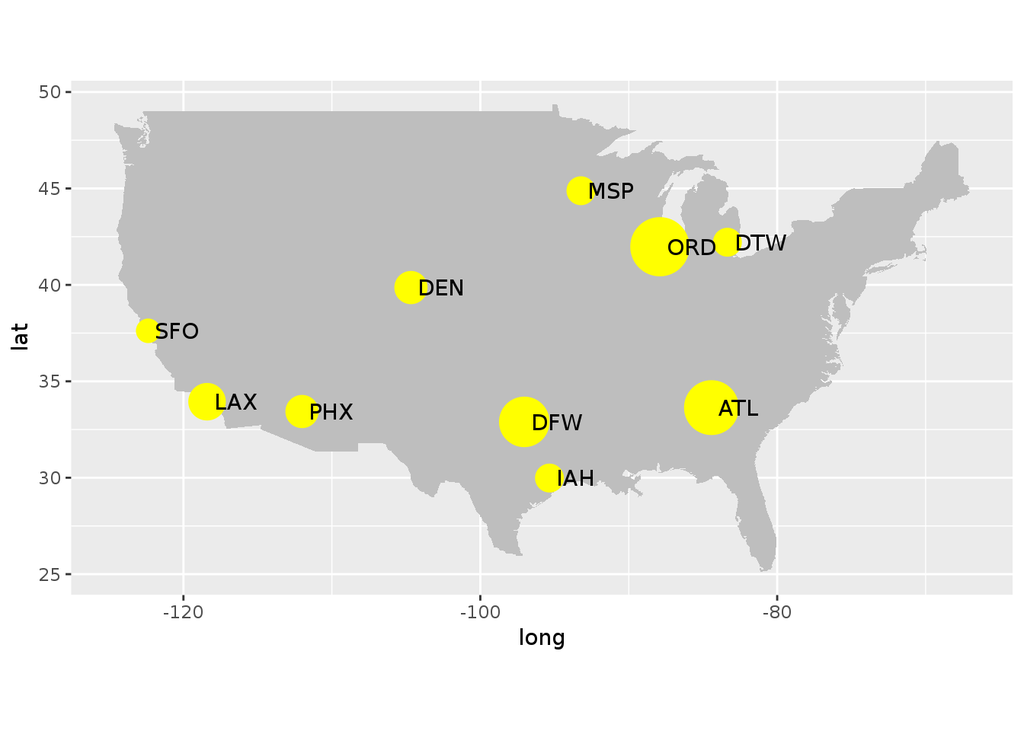

```r
base_map +
  geom_point(data = top_10, aes(x = lon, y = lat), colour = "yellow",
             size = top_10$n) +
  geom_text(data = top_10,
            aes(x = lon, y = lat, label =
                  paste(" ", as.character(dest), sep = "")), angle = 0,
            hjust = 0, color = "black") +
  coord_fixed(1.3)
```

0. Map the top 10 busiest direct routes. Size of lines should reflect the number of flights through that route.

```r
top_droute <- flights_tbl %>%
  group_by(origin, dest) %>%
  count() %>%
  arrange(desc(n)) %>%
  collect()
top_droute
```

```
## # A tibble: 8,608 x 3
## # Groups:   origin, dest [8,608]
##    origin dest        n
##    <chr>  <chr>   <dbl>
##  1 SFO    LAX   338472.
##  2 LAX    SFO   336938.
##  3 LAX    LAS   292125.
##  4 LAS    LAX   286328.
##  5 PHX    LAX   279716.
##  6 LAX    PHX   279116.
##  7 ORD    MSP   249960.
##  8 MSP    ORD   249250.
##  9 PHX    LAS   240587.
## 10 LAS    PHX   239183.
## # ... with 8,598 more rows
```

```r
#combine data set

top_10_route <- as.data.frame(head(top_droute, 10), stringAsFactors = FALSE)
top_10_route
```

```
##    origin dest      n
## 1     SFO  LAX 338472
## 2     LAX  SFO 336938
## 3     LAX  LAS 292125
## 4     LAS  LAX 286328
## 5     PHX  LAX 279716
## 6     LAX  PHX 279116
## 7     ORD  MSP 249960
## 8     MSP  ORD 249250
## 9     PHX  LAS 240587
## 10    LAS  PHX 239183
```

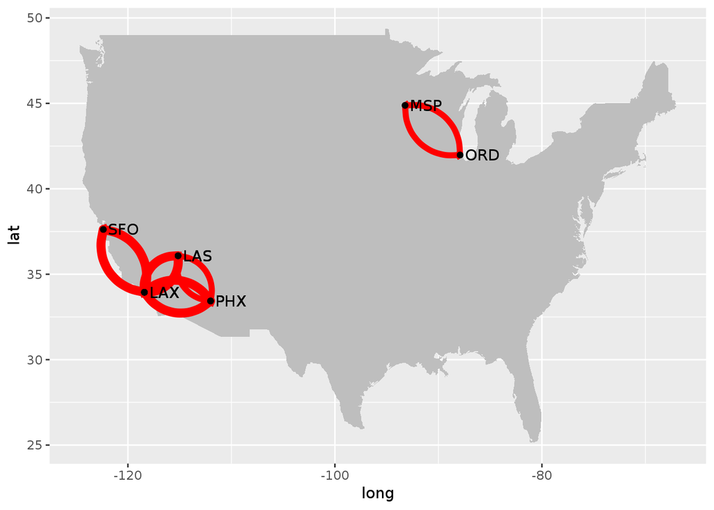

```r
#combine dataset by origin=faa to get lat and lon
top_10_route1 <- inner_join(top_10_route, airports_tbl,
                            by = c("origin" = "faa"), copy = TRUE) %>%
  rename(lat1 = lat, lon1 = lon)
top_10_route1 <- inner_join(top_10_route1, airports_tbl,
                            by = c("dest" = "faa"), copy = TRUE) %>%
  rename(lat2 = lat, lon2 = lon)
top_10_route2 <- top_10_route1 %>%
  select(origin, dest, lat1, lat2, lon1, lon2, n)
top_10_route2$lat1 <- as.numeric(top_10_route2$lat1)
top_10_route2$lat2 <- as.numeric(top_10_route2$lat2)
top_10_route2$lon1 <- as.numeric(top_10_route2$lon1)
top_10_route2$lon2 <- as.numeric(top_10_route2$lon2)
top_10_route2$n <- as.numeric(top_10_route2$n)
top_10_route2$size <- round(top_10_route2$n / 100000)


base_map +
  geom_curve(data = top_10_route2,
             aes(x = lon1, y = lat1, xend = lon2, yend = lat2),
             arrow = arrow(length = unit(0.01, "npc")),
             size = top_10_route2$size, color = "red") +
  geom_point(data = top_10_route2, aes(x = lon1, y = lat1), colour = "black") +
  geom_point(data = top_10_route2, aes(x = lon2, y = lat2), colour = "black") +
  geom_text(data = top_10_route2,
            aes(x = lon1, y = lat1, label =
                  paste(" ", as.character(origin), sep = "")), angle = 0,
            hjust = 0, color = "black")
```

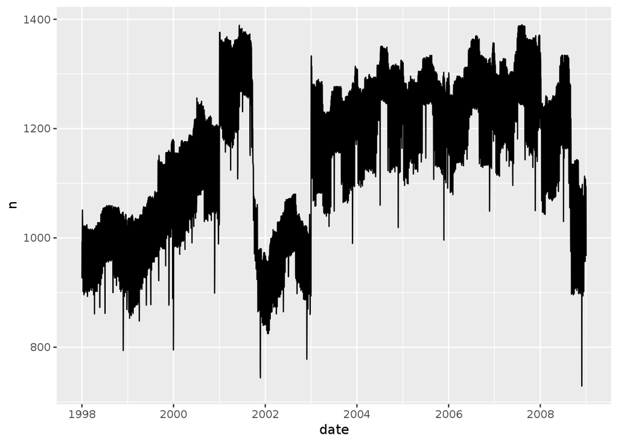

```r
LAX_AT <- flights_tbl %>%
  filter(dest == "LAX" | origin == "LAX") %>%
  select(year, month, dayofmonth, dayofweek)

LAX_air_traffic <- LAX_AT %>%
  select(year, month, dayofmonth) %>%
  group_by(year, month, dayofmonth) %>%
  count() %>%
  arrange(year, month, dayofmonth) %>%
  collect()

#head(LAX_air_traffic)

LAX_air_traffic1 <- LAX_air_traffic %>%
  filter(year >= 1998 & year < 2009) %>%
  mutate(date = paste(year, month, dayofmonth, sep = "-"))
#head(LAX_air_traffic1)
LAX_air_traffic1$date <- as.Date(LAX_air_traffic1$date, format = "%Y-%m-%d")
#head(LAX_air_traffic1)

LAX_air_traffic1 %>%
  ggplot(aes(x = date, y = n)) +
  geom_path() +
  scale_x_date()
```

```
(b). Visualize and explain seasonal effects.
```

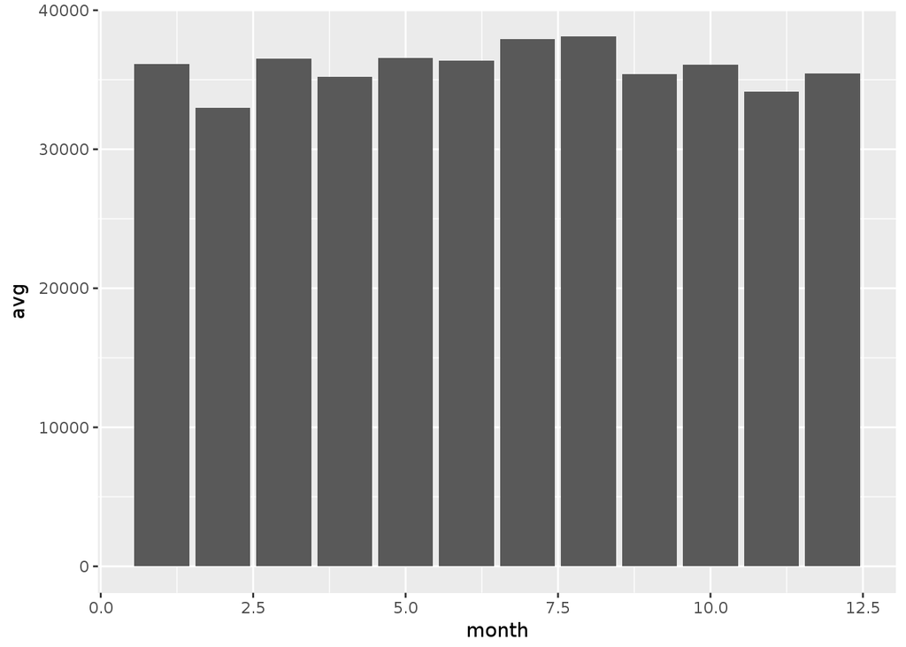

```r
seasonal_effect <- LAX_AT %>%
  filter(year >= 1998 & year < 2009) %>%
  select(year, month) %>%
  group_by(year, month) %>%
  count() %>%
  arrange(year, month) %>%
  collect()

seasonal_effect %>%
  group_by(month) %>%
  summarise(avg = mean(n, na.rm = TRUE)) %>%
  ggplot() +
  geom_col(aes(x = month, y = avg))
```

Based on average air traffic from year 1998 to year 2008, we can see that FEB is less busier than other months while July and August are busier than other months.

```
(c). Visualize and explain weekly effects.
```

```r
head(LAX_AT)
```

```
## # Source:   lazy query [?? x 4]
## # Database: spark_connection
##    year month dayofmonth dayofweek
##   <int> <int>      <int>     <int>
## 1  1987    10          1         4
## 2  1987    10          2         5
## 3  1987    10          5         1
## 4  1987    10          6         2
## 5  1987    10          8         4
## 6  1987    10         13         2
```

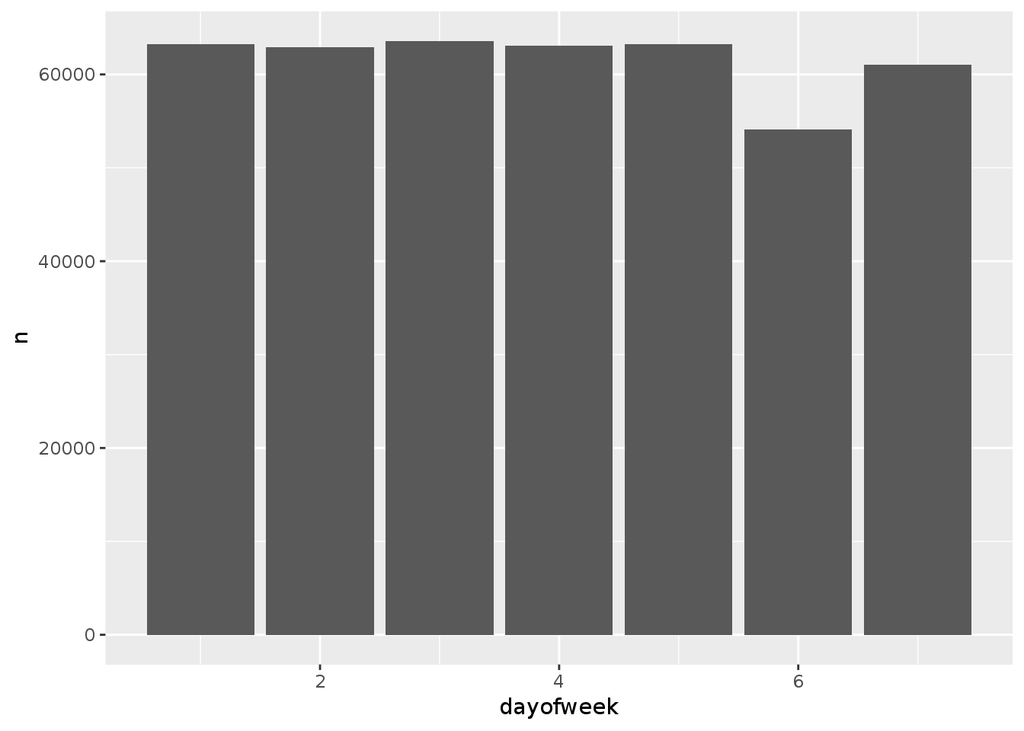

```r
weekly_effect <- LAX_AT %>%
  filter(year == 2008) %>%
  select(dayofweek) %>%
  group_by(dayofweek) %>%
  count() %>%
  arrange(dayofweek) %>%
  collect()
weekly_effect %>%
  ggplot() +
  geom_col(aes(x = dayofweek, y = n))
```

In 2008, LAX has the lowest average air traffic on Sat while weekdays have about the same air traffic.

```
(d). Map top 10 destinations from LAX. Size of dots should reflect the number of flights from LAX to that destination.
```

```r
top_lax <- flights_tbl %>%
  filter(origin == "LAX" & year == "2008") %>%
  select(dest) %>%
  group_by(dest) %>%
  count() %>%
  arrange(desc(n))
top_lax
```

```
## # Source:     lazy query [?? x 2]
## # Database:   spark_connection
## # Groups:     dest
## # Ordered by: desc(n)
##    dest       n
##    <chr>  <dbl>
##  1 SFO   13390.
##  2 LAS   11773.
##  3 SAN   11257.
##  4 PHX    9897.
##  5 SJC    8908.
##  6 DEN    8894.
##  7 JFK    8058.
##  8 OAK    7583.
##  9 ORD    7333.
## 10 SEA    6876.
## # ... with more rows
```

```r
top_10_lax <- as.data.frame(head(top_lax, 10))
top_10_lax1 <- top_10_lax %>%
  left_join(airports_tbl, by = c("dest" = "faa"), copy = TRUE) %>%
  select(dest, lat, lon, n)
top_10_lax1$lat <- as.numeric(top_10_lax1$lat)
top_10_lax1$lon <- as.numeric(top_10_lax1$lon)
top_10_lax1$n <- as.numeric(top_10_lax1$n)
top_10_lax1$size <- round(top_10_lax1$n / 1000)

top_10_lax1
```

```
##    dest     lat       lon     n size
## 1   SFO 37.6190 -122.3750 13390   13
## 2   LAS 36.0801 -115.1520 11773   12
## 3   SAN 32.7336 -117.1900 11257   11
## 4   PHX 33.4343 -112.0120  9897   10
## 5   SJC 37.3626 -121.9290  8908    9
## 6   DEN 39.8617 -104.6730  8894    9
## 7   JFK 40.6398  -73.7789  8058    8
## 8   OAK 37.7213 -122.2210  7583    8
## 9   ORD 41.9786  -87.9048  7333    7
## 10  SEA 47.4490 -122.3090  6876    7
```

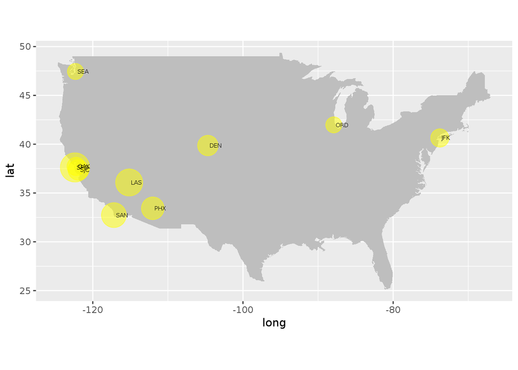

```r
base_map +
  geom_point(data = top_10_lax1, aes(x = lon, y = lat), color = "yellow",
             size = top_10_lax1$size, alpha = 0.5) +
  geom_text(data = top_10_lax1,
            aes(x = lon, y = lat, label =
                  paste(" ", as.character(dest), sep = "")), angle = 0,
            hjust = 0, color = "black", size = 2) +
  coord_fixed(1.3)
```

0. Build a predictive model for the arrival delay (`arrdelay`) of flights flying from LAX. Use the same filtering criteria as in the [lecture notes](http://hua-zhou.github.io/teaching/biostatm280-2018winter/slides/12-sparklyr/sparklyr-flights.html) to construct training and validation sets. You are allowed to use a maximum of 5 predictors. The prediction performance of your model on the validation data set will be an important factor for grading this question.

```r
#might be overfitting -> predict mean squared (minimize this) -> compare with the training model -> final testing
#fit a linear reg model of arrdelay on distance, carriers, depdelay
model_data <- flights_tbl %>%
  filter(origin == "LAX") %>%
  filter(!is.na(arrdelay) & !is.na(depdelay) & !is.na(distance)) %>%
  filter(depdelay > 15 & depdelay < 240) %>%
  filter(arrdelay > -60 & arrdelay < 360) %>%
  filter(year >= 2003 & year <= 2007) %>%
  left_join(airlines_tbl, by = c("uniquecarrier" = "code"), copy = TRUE) %>%
  filter(!is.na(uniquecarrier)) %>%
  select(year, month, distance, uniquecarrier, description,
         dest, origin, arrdelay, depdelay)



#summarize data by carrier
#linear reg model of arrdelay on distance, carriers, depdelay
model_data %>%
  group_by(uniquecarrier) %>%
  summarize(description = min(description, na.rm = TRUE),
            distance = mean(distance, na.rm = TRUE),
            arrdelay = mean(arrdelay, na.rm = TRUE),
            depdelay = mean(depdelay, na.rm = TRUE)) %>%
  select(uniquecarrier, description, distance, arrdelay, depdelay) %>%
  arrange(arrdelay)
```

```
## # Source:     lazy query [?? x 5]
## # Database:   spark_connection
## # Ordered by: arrdelay
##    uniquecarrier description                    distance arrdelay depdelay
##    <chr>         <chr>                             <dbl>    <dbl>    <dbl>
##  1 WN            Southwest Airlines Co.             626.     37.4     41.5
##  2 F9            Frontier Airlines Inc.             782.     41.1     41.6
##  3 MQ            Envoy Air                          233.     42.1     42.9
##  4 OO            SkyWest Airlines Inc.              254.     42.4     42.6
##  5 DL            Delta Air Lines Inc.              1931.     42.9     45.5
##  6 FL            AirTran Airways Corporation       1824.     43.1     46.0
##  7 US            US Airways Inc.                   1383.     43.1     45.4
##  8 AS            Alaska Airlines Inc.               938.     43.7     46.5
##  9 NW            Northwest Airlines Inc.           1660.     43.8     47.7
## 10 HP            America West Airlines Inc. (M…     702.     45.3     47.4
## # ... with more rows
```

```r
#partition the data into training and validation sets
model_partition <- model_data %>%
  sdf_partition(train = 0.8, valid = 0.2, seed = 5555)
#fit a linear model
system.time(
  model1 <- model_partition$train %>%
    ml_linear_regression(arrdelay ~ distance + depdelay + uniquecarrier)
)
```

```
##    user  system elapsed
##   0.248   0.004 373.230
```

```r
#summarize the linear model
summary(model1)
```

```
## Call: ml_linear_regression.tbl_spark(., arrdelay ~ distance + depdelay + uniquecarrier)
##
## Deviance Residuals (approximate):
##      Min       1Q   Median       3Q      Max
## -193.783   -7.115   -1.397    5.121  332.315
##
## Coefficients:
##      (Intercept)         distance         depdelay uniquecarrier_WN
##     13.103526082     -0.002873967      1.012079861    -15.848562892
## uniquecarrier_OO uniquecarrier_AA uniquecarrier_UA uniquecarrier_DL
##    -13.117683727    -10.558071086    -12.617062290    -10.614339186
## uniquecarrier_AS uniquecarrier_MQ uniquecarrier_CO uniquecarrier_NW
##    -13.811574486    -13.675496645     -9.259696070    -12.940403310
## uniquecarrier_US uniquecarrier_HP uniquecarrier_XE uniquecarrier_F9
##    -12.072019785    -13.582976280    -12.166077196    -11.791236820
## uniquecarrier_TZ uniquecarrier_FL uniquecarrier_EV uniquecarrier_YV
##     -9.326579273    -11.062595430    -12.833599265    -13.808264210
## uniquecarrier_HA
##    -13.617262195
##
## R-Squared: 0.8845
## Root Mean Squared Error: 13.35
```

assess model performance: compare the model performance using the validation data

```r
#not enough resources to run this
system.time(
  model_deciles <- lapply(model_partition, function(x) {
    sdf_predict(model1, x) %>%
      mutate(decile = ntile(desc(prediction), 10)) %>%
      group_by(decile) %>%
      summarize(arrdelay = mean(arrdelay, na.rm = TRUE)) %>%
      select(decile, arrdelay) %>%
      collect()
  })
)


model_deciles

deciles <- rbind(
  data.frame(data = 'train', model_deciles$train),
  data.frame(data = 'valid', model_deciles$valid),
  make.row.names = FALSE
)
deciles

deciles %>%
  ggplot(aes(factor(decile), arrdelay, fill = data)) +
  geom_bar(stat = 'identity', position = 'dodge') +
  labs(title = 'Average arrival delay by predicted decile', x = 'Arrival Delay', y = 'Minutes')

sdf_predict(model1, model_partition$valid) %>%
  mutate(res = prediction - arrdelay) %>%
  summarise(mse = mean(res^2, na.rm = TRUE))
```

```r
#Because we don't have enough resources to compare the model performance using the validation data, run this instead.
# Calculate average arrdelay by predicted decile
model_deciles <- sdf_predict(model1, model_partition$valid) %>%
  mutate(decile = ntile(desc(prediction), 10)) %>%
  group_by(decile) %>%
  summarize(arrdelay = mean(arrdelay, na.rm = TRUE)) %>%
  select(decile, arrdelay) %>%
  collect()

model_deciles

#calculate mse of predicted values and actual validation values
sdf_predict(model1, model_partition$valid) %>%
  mutate(res = prediction - arrdelay) %>%
  summarise(mse = mean(res^2, na.rm = TRUE))
```

[output not shown]

test data

```r
data_2008 <- flights_tbl %>%
  filter(origin == "LAX") %>%
  filter(!is.na(arrdelay) & !is.na(depdelay) & !is.na(distance)) %>%
  filter(depdelay > 15 & depdelay < 240) %>%
  filter(arrdelay > -60 & arrdelay < 360) %>%
  filter(year == 2008) %>%
  left_join(airlines_tbl, by = c("uniquecarrier" = "code"), copy = TRUE) %>%
  select(year, month, distance, uniquecarrier, description,
         dest, origin, arrdelay, depdelay)
data_2008
```

```
## # Source:   lazy query [?? x 9]
## # Database: spark_connection
##     year month distance uniquecarrier description    dest  origin arrdelay
##    <int> <int>    <int> <chr>         <chr>          <chr> <chr>     <int>
##  1  2008     1      677 WN            Southwest Air… ABQ   LAX          15
##  2  2008     1      677 WN            Southwest Air… ABQ   LAX          32
##  3  2008     1     1797 WN            Southwest Air… BNA   LAX          42
##  4  2008     1     1797 WN            Southwest Air… BNA   LAX          22
##  5  2008     1      714 WN            Southwest Air… ELP   LAX          96
##  6  2008     1      714 WN            Southwest Air… ELP   LAX          15
##  7  2008     1     1390 WN            Southwest Air… HOU   LAX          66
##  8  2008     1     1390 WN            Southwest Air… HOU   LAX          34
##  9  2008     1      236 WN            Southwest Air… LAS   LAX          24
## 10  2008     1      236 WN            Southwest Air… LAS   LAX          33
## # ... with more rows, and 1 more variable: depdelay <int>
```

```r
#group by carrier

test_result <- sdf_predict(model1, data_2008) %>%
  group_by(description) %>%
  summarize(arrdelay = mean(arrdelay, na.rm = TRUE),
            prediction = mean(prediction, na.rm = TRUE), freq = n()) %>%
  filter(freq > 10000) %>%
  collect()

test_result
```

```
## # A tibble: 0 x 4
## # ... with 4 variables: description <chr>, arrdelay <dbl>,
## #   prediction <dbl>, freq <dbl>
```

```r
#test mse
sdf_predict(model1, data_2008) %>%
  mutate(res = prediction - arrdelay) %>%
  summarise(mse = mean(res^2, na.rm = TRUE))
```

```
## # Source:   lazy query [?? x 1]
## # Database: spark_connection
##     mse
##   <dbl>
## 1  203.
```

[figure not shown]

```r
ggplot(test_result, aes(arrdelay, prediction)) +
  geom_point(alpha = 0.75, color = 'red', shape = 3) +
  geom_abline(intercept = 0, slope = 1, alpha = 0.15, color = 'blue') +
  geom_text(aes(label = substr(description, 1, 20)), size = 3, alpha = 0.75, vjust = -1) +
  labs(title='Average Arrival Delay Forecast', x = 'Actual', y = 'Predicted')
```

0. Visualize and explain any other information you want to explore. Top 10 airlines in 2008

```r
top_airlines <- flights_tbl %>%
  filter(year == 2008 & !is.na(uniquecarrier) & cancelled == 0) %>%
  select(uniquecarrier) %>%
  group_by(uniquecarrier) %>%
  count() %>%
  left_join(airlines_tbl, by = c("uniquecarrier" = "code"), copy = TRUE) %>%
  arrange(desc(n))

top_10_airlines <- as.data.frame(head(top_airlines, 10))
top_10_airlines
```

```
##    uniquecarrier       n                  description
## 1             WN 1189365       Southwest Airlines Co.
## 2             AA  587445       American Airlines Inc.
## 3             OO  554723        SkyWest Airlines Inc.
## 4             MQ  472362                    Envoy Air
## 5             US  447007              US Airways Inc.
## 6             DL  445118         Delta Air Lines Inc.
## 7             UA  438974        United Air Lines Inc.
## 8             XE  364518 ExpressJet Airlines Inc. (1)
## 9             NW  344746      Northwest Airlines Inc.
## 10            CO  294753   Continental Air Lines Inc.
```

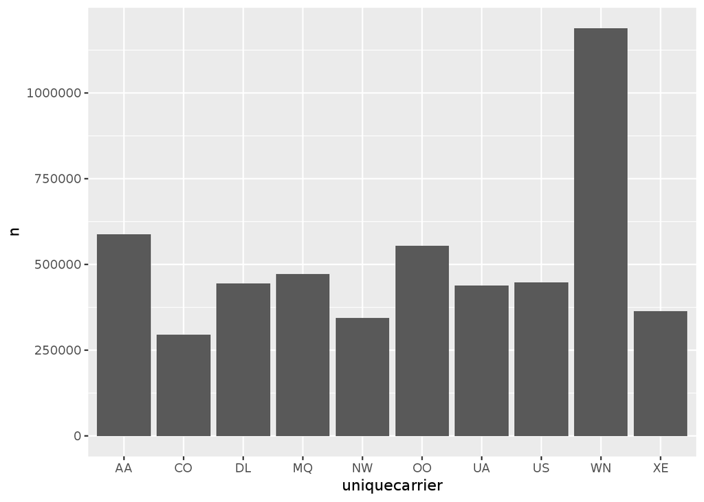

```r
top_10_airlines %>%
  ggplot() +
  geom_col(aes(x = uniquecarrier, y = n))
```

In 2008, Southwest was the top 1 airlines in number of flights (1189365 flights), and American Airlines ranked 2.

```r
spark_disconnect_all()
```

```
## [1] 1
```